# flight-predication

```python
# This Python 3 environment comes with many helpful analytics libraries installed
# It is defined by the kaggle/python Docker image: https://github.com/kaggle/docker-python
# For example, here's several helpful packages to load

import numpy as np # linear algebra
import pandas as pd # data processing, CSV file I/O (e.g. pd.read_csv)
import re
import datetime as dt
import plotly.express as px
from matplotlib import pyplot as plt
import seaborn as sns
from sklearn.preprocessing import StandardScaler
from sklearn.model_selection import train_test_split
from sklearn.linear_model import LinearRegression
from sklearn.metrics import r2_score,mean_squared_error
from sklearn.metrics import mean_absolute_percentage_error
from sklearn.ensemble import RandomForestRegressor
from sklearn.tree import DecisionTreeRegressor
from sklearn.ensemble import GradientBoostingRegressor
from sklearn.ensemble import AdaBoostRegressor
from sklearn.neighbors import KNeighborsRegressor
from xgboost import XGBRegressor
from plotly.offline import init_notebook_mode
init_notebook_mode(connected=True)
from sklearn.model_selection import RandomizedSearchCV,GridSearchCV
from sklearn.model_selection import KFold
```

```python
!pip install openpyxl
```

```python
flight=pd.read_csv('data_train.csv')
flight.head(3)
```

|  | Unnamed: 0 | Airline | Date_of_Journey | Source | Destination | Route | Dep_Time | Arrival_Time | Duration | Total_Stops | Additional_Info | Price |
| --- | --- | --- | --- | --- | --- | --- | --- | --- | --- | --- | --- | --- |
| 0 | 0 | IndiGo | 24/03/2019 | Banglore | New Delhi | BLR → DEL | 22:20 | 01:10 22 Mar | 2h 50m | non-stop | No info | 3897 |
| 1 | 1 | Air India | 1/05/2019 | Kolkata | Banglore | CCU → IXR → BBI → BLR | 05:50 | 13:15 | 7h 25m | 2 stops | No info | 7662 |
| 2 | 2 | Jet Airways | 9/06/2019 | Delhi | Cochin | DEL → LKO → BOM → COK | 09:25 | 04:25 10 Jun | 19h | 2 stops | No info | 13882 |

```python
flight.to_csv('data_train.csv')
```

## Shape of the Dataset

```python
flight.shape
```

```
(10683, 12)
```

## Checking Column Datatype

```python
flight.info()
```

```
<class 'pandas.core.frame.DataFrame'>
RangeIndex: 10683 entries, 0 to 10682
Data columns (total 12 columns):
 #   Column           Non-Null Count  Dtype
---  ------           --------------  -----
 0   Unnamed: 0       10683 non-null  int64
 1   Airline          10683 non-null  object
 2   Date_of_Journey  10683 non-null  object
 3   Source           10683 non-null  object
 4   Destination      10683 non-null  object
 5   Route            10682 non-null  object
 6   Dep_Time         10683 non-null  object
 7   Arrival_Time     10683 non-null  object
 8   Duration         10683 non-null  object
 9   Total_Stops      10682 non-null  object
 10  Additional_Info  10683 non-null  object
 11  Price            10683 non-null  int64
dtypes: int64(2), object(10)
memory usage: 1001.7+ KB
```

- Here `Date_of_journey` Column is not correct Datatypes
- `Route` and `Total_stops` Column has 1 `Nan` Value

## Check The Summary of Each Column

```python
flight.describe()
```

|  | Unnamed: 0 | Price |
| --- | --- | --- |
| count | 10683.000000 | 10683.000000 |
| mean | 5341.000000 | 9087.064121 |
| std | 3084.060797 | 4611.359167 |
| min | 0.000000 | 1759.000000 |
| 25% | 2670.500000 | 5277.000000 |
| 50% | 5341.000000 | 8372.000000 |
| 75% | 8011.500000 | 12373.000000 |
| max | 10682.000000 | 79512.000000 |

```python
flight.describe(include=['object'])
```

|  | Airline | Date_of_Journey | Source | Destination | Route | Dep_Time | Arrival_Time | Duration | Total_Stops | Additional_Info |
| --- | --- | --- | --- | --- | --- | --- | --- | --- | --- | --- |
| count | 10683 | 10683 | 10683 | 10683 | 10682 | 10683 | 10683 | 10683 | 10682 | 10683 |
| unique | 12 | 44 | 5 | 6 | 128 | 222 | 1343 | 368 | 5 | 10 |
| top | Jet Airways | 18/05/2019 | Delhi | Cochin | DEL → BOM → COK | 18:55 | 19:00 | 2h 50m | 1 stop | No info |
| freq | 3849 | 504 | 4537 | 4537 | 2376 | 233 | 423 | 550 | 5625 | 8345 |

## Checking For Missing Value

```python
flight.isna().sum()
```

```
Unnamed: 0         0
Airline            0
Date_of_Journey    0
Source             0
Destination        0
Route              1
Dep_Time           0
Arrival_Time       0
Duration           0
Total_Stops        1
Additional_Info    0
Price              0
dtype: int64
```

```python
px.density_heatmap(data_frame=flight.isna().sum())
```

[interactive chart not shown]

```python
flight=flight.dropna()
```

## Data Cleaning

```python
## Changing Date of Journey column Datatype
flight['Date_of_Journey']=pd.to_datetime(flight['Date_of_Journey'])
```

```python
## only taking arrival time ie hr:min some of values are '12:56 10 Mar'
pattern='\d{2}:\d{2}'
flight['Arrival_Time']=flight['Arrival_Time'].apply(lambda x:re.findall(pattern,x)[0])
```

```python
flight.head(2)
```

|  | Unnamed: 0 | Airline | Date_of_Journey | Source | Destination | Route | Dep_Time | Arrival_Time | Duration | Total_Stops | Additional_Info | Price |
| --- | --- | --- | --- | --- | --- | --- | --- | --- | --- | --- | --- | --- |
| 0 | 0 | IndiGo | 2019-03-24 | Banglore | New Delhi | BLR → DEL | 22:20 | 01:10 | 2h 50m | non-stop | No info | 3897 |
| 1 | 1 | Air India | 2019-01-05 | Kolkata | Banglore | CCU → IXR → BBI → BLR | 05:50 | 13:15 | 7h 25m | 2 stops | No info | 7662 |

- In `Duration` Column Adding 00m Where only Hr is given
- After that we Calualate total duration in minutes

```python
pattern='\d{1,2}\w\s\d{2}\w'
```

```python
Time=[]
for time in flight['Duration']:
    if re.findall(pattern,time):
        Time.append(time)
    else:
        time=time+' '+'00m'
        Time.append(time)
```

```python
flight['Duration']=Time
```

```python
hour=flight['Duration'].apply(lambda x:x.split(' ')[0][:-1]).astype('int')
minute=flight['Duration'].apply(lambda x:x.split(' ')[1][:-1]).astype('int')
flight['Duration']=hour*60+minute
```

```python
flight.head(2)
```

|  | Unnamed: 0 | Airline | Date_of_Journey | Source | Destination | Route | Dep_Time | Arrival_Time | Duration | Total_Stops | Additional_Info | Price |
| --- | --- | --- | --- | --- | --- | --- | --- | --- | --- | --- | --- | --- |
| 0 | 0 | IndiGo | 2019-03-24 | Banglore | New Delhi | BLR → DEL | 22:20 | 01:10 | 170 | non-stop | No info | 3897 |
| 1 | 1 | Air India | 2019-01-05 | Kolkata | Banglore | CCU → IXR → BBI → BLR | 05:50 | 13:15 | 445 | 2 stops | No info | 7662 |

## Extract the Date , Month ,week from Date_of_Journey

```python
flight['week']=flight['Date_of_Journey'].dt.week
flight['Day_name']=flight['Date_of_Journey'].dt.day_name()
flight['month_name']=flight['Date_of_Journey'].dt.month_name()
flight['month']=flight['Date_of_Journey'].dt.month
flight['Day']=flight['Date_of_Journey'].dt.day
```

```python
flight.head(2)
```

|  | Unnamed: 0 | Airline | Date_of_Journey | Source | Destination | Route | Dep_Time | Arrival_Time | Duration | Total_Stops | Additional_Info | Price | week | Day_name | month_name | month | Day |
| --- | --- | --- | --- | --- | --- | --- | --- | --- | --- | --- | --- | --- | --- | --- | --- | --- | --- |
| 0 | 0 | IndiGo | 2019-03-24 | Banglore | New Delhi | BLR → DEL | 22:20 | 01:10 | 170 | non-stop | No info | 3897 | 12 | Sunday | March | 3 | 24 |
| 1 | 1 | Air India | 2019-01-05 | Kolkata | Banglore | CCU → IXR → BBI → BLR | 05:50 | 13:15 | 445 | 2 stops | No info | 7662 | 1 | Saturday | January | 1 | 5 |

```python
flight.drop('Date_of_Journey',axis=1,inplace=True)
```

```python
flight.head(2)
```

|  | Unnamed: 0 | Airline | Source | Destination | Route | Dep_Time | Arrival_Time | Duration | Total_Stops | Additional_Info | Price | week | Day_name | month_name | month | Day |
| --- | --- | --- | --- | --- | --- | --- | --- | --- | --- | --- | --- | --- | --- | --- | --- | --- |
| 0 | 0 | IndiGo | Banglore | New Delhi | BLR → DEL | 22:20 | 01:10 | 170 | non-stop | No info | 3897 | 12 | Sunday | March | 3 | 24 |
| 1 | 1 | Air India | Kolkata | Banglore | CCU → IXR → BBI → BLR | 05:50 | 13:15 | 445 | 2 stops | No info | 7662 | 1 | Saturday | January | 1 | 5 |

## Exploratory Data Analysis

```python
def unvairate(data,col):
    df=data[col].value_counts(normalize=True).reset_index()
    fig=px.pie(names=df['index'],values=df[col])
    fig.show()

def bivariate(data,col):
    fig=px.bar(data_frame=data,x=col,y='Price',color=col)
    fig.update_traces(dict(marker_line_width=0))
    fig.show()
```

```python
unvairate(flight,'Airline')
bivariate(flight,'Airline')
```

[interactive chart not shown]

- People use Jet Airways more than the other Airline.
- Jetways Airline is also expensive among all.

```python
unvairate(flight,'Source')
bivariate(flight,'Source')
```

[interactive chart not shown]

- 42.5% flights starts from Delhi.
- In Price also It is high

```python
unvairate(flight,'Destination')
bivariate(flight,'Destination')
```

[interactive chart not shown]

- As we see More number People prefer to Go to Kochin,Banglore than other states.

```python
unvairate(flight,'Total_Stops')
bivariate(flight,'Total_Stops')
```

[interactive chart not shown]

- Flight Which have 1 Stops has higher in Price

```python
unvairate(flight,'month_name')
bivariate(flight,'month_name')
```

[interactive chart not shown]

- In Month of June ,May ,March Prices More.

```python
unvairate(flight,'Day_name')
bivariate(flight,'Day_name')
```

[interactive chart not shown]

- Prices are More on Thursday in comparion to other days while friday and Monday have high Price.

```python
unvairate(flight,'week')
bivariate(flight,'week')
```

[interactive chart not shown]

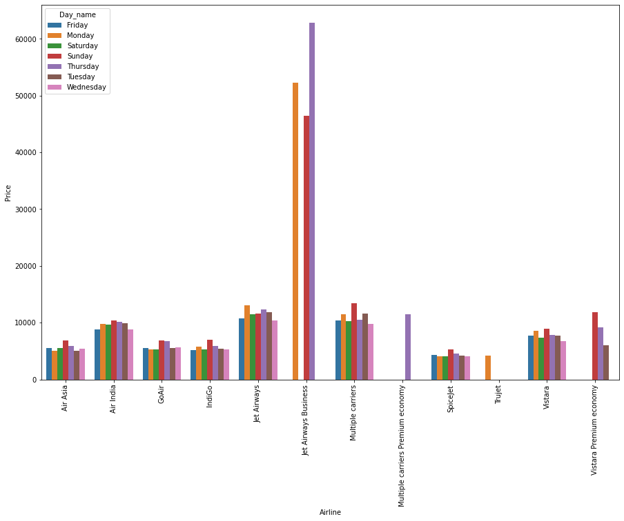

```python
Airline_Day_name=(flight.groupby(['Airline','Day_name'])['Price'].mean().reset_index())
plt.figure(figsize=(15,10))
sns.barplot(data=Airline_Day_name,x='Airline',y='Price',hue='Day_name')
plt.xticks(rotation=90)
plt.show()
```

- Jet Airways Bussiness Class has highest Price among all the other flighs

```python
(flight.drop(['Day_name','month_name','week'],1,inplace=True))
```

```python
## creating new col from dep_time .
flight['Dep_hour']=(flight['Dep_Time'].apply(lambda x:x.split(':')[0])).astype('int')
flight['Dep_min']=(flight['Dep_Time'].apply(lambda x:x.split(':')[1])).astype('int')
```

```python
## creating new col from arrival_time
flight['Arrival_hour']=(flight['Arrival_Time'].apply(lambda x:x.split(':')[0])).astype('int')
flight['Arrival_min']=(flight['Arrival_Time'].apply(lambda x:x.split(':')[1])).astype('int')
```

```python
flight.drop(['Arrival_Time','Dep_Time'],1,inplace=True)
```

```python
flight['Total_Stops'].value_counts()
```

```
1 stop      5625
non-stop    3491
2 stops     1520
3 stops       45
4 stops        1
Name: Total_Stops, dtype: int64
```

```python
# As this is case of Ordinal Categorical type we perform LabelEncoder
# Here Values are assigned with corresponding keys
flight['Total_Stops']=flight['Total_Stops'].replace({"1 stop":1,'non-stop':0,'2 stops':2,'3 stops':3,'4 stops':3})
```

```python
flight['Total_Stops'].value_counts()
```

```
1    5625
0    3491
2    1520
3      46
Name: Total_Stops, dtype: int64
```

```python
flight['Additional_Info'].value_counts(normalize=True)
```

```
No info                         0.781127
In-flight meal not included     0.185546
No check-in baggage included    0.029957
1 Long layover                  0.001779
Change airports                 0.000655
Business class                  0.000374
No Info                         0.000281
1 Short layover                 0.000094
Red-eye flight                  0.000094
2 Long layover                  0.000094
Name: Additional_Info, dtype: float64
```

- In This feature doesnt add information to the Predicted varibale so we remove it

```python
# Additional_Info contains almost 80% no_info
flight.drop(['Additional_Info'],1,inplace=True)
```

- Route Columns and Total_stops Convey the same information So we remove Route col from it.

```python
flight
```

|  | Unnamed: 0 | Airline | Source | Destination | Route | Duration | Total_Stops | Price | month | Day | Dep_hour | Dep_min | Arrival_hour | Arrival_min |
| --- | --- | --- | --- | --- | --- | --- | --- | --- | --- | --- | --- | --- | --- | --- |
| 0 | 0 | IndiGo | Banglore | New Delhi | BLR → DEL | 170 | 0 | 3897 | 3 | 24 | 22 | 20 | 1 | 10 |
| 1 | 1 | Air India | Kolkata | Banglore | CCU → IXR → BBI → BLR | 445 | 2 | 7662 | 1 | 5 | 5 | 50 | 13 | 15 |
| 2 | 2 | Jet Airways | Delhi | Cochin | DEL → LKO → BOM → COK | 1140 | 2 | 13882 | 9 | 6 | 9 | 25 | 4 | 25 |
| 3 | 3 | IndiGo | Kolkata | Banglore | CCU → NAG → BLR | 325 | 1 | 6218 | 12 | 5 | 18 | 5 | 23 | 30 |
| 4 | 4 | IndiGo | Banglore | New Delhi | BLR → NAG → DEL | 285 | 1 | 13302 | 1 | 3 | 16 | 50 | 21 | 35 |
| ... | ... | ... | ... | ... | ... | ... | ... | ... | ... | ... | ... | ... | ... | ... |
| 10678 | 10678 | Air Asia | Kolkata | Banglore | CCU → BLR | 150 | 0 | 4107 | 9 | 4 | 19 | 55 | 22 | 25 |
| 10679 | 10679 | Air India | Kolkata | Banglore | CCU → BLR | 155 | 0 | 4145 | 4 | 27 | 20 | 45 | 23 | 20 |
| 10680 | 10680 | Jet Airways | Banglore | Delhi | BLR → DEL | 180 | 0 | 7229 | 4 | 27 | 8 | 20 | 11 | 20 |
| 10681 | 10681 | Vistara | Banglore | New Delhi | BLR → DEL | 160 | 0 | 12648 | 1 | 3 | 11 | 30 | 14 | 10 |
| 10682 | 10682 | Air India | Delhi | Cochin | DEL → GOI → BOM → COK | 500 | 2 | 11753 | 9 | 5 | 10 | 55 | 19 | 15 |

10682 rows × 14 columns

```python
flight['Destination']=(flight['Destination'].replace({'New Delhi':'Delhi'}))
```

```python
flight['Destination'].value_counts()
```

```
Cochin       4536
Banglore     2871
Delhi        2197
Hyderabad     697
Kolkata       381
Name: Destination, dtype: int64
```

```python
## dropping the Route col from dataset
flight.drop(['Route'],1,inplace=True)
```

```python
flight.head()
```

|  | Unnamed: 0 | Airline | Source | Destination | Duration | Total_Stops | Price | month | Day | Dep_hour | Dep_min | Arrival_hour | Arrival_min |
| --- | --- | --- | --- | --- | --- | --- | --- | --- | --- | --- | --- | --- | --- |
| 0 | 0 | IndiGo | Banglore | Delhi | 170 | 0 | 3897 | 3 | 24 | 22 | 20 | 1 | 10 |
| 1 | 1 | Air India | Kolkata | Banglore | 445 | 2 | 7662 | 1 | 5 | 5 | 50 | 13 | 15 |
| 2 | 2 | Jet Airways | Delhi | Cochin | 1140 | 2 | 13882 | 9 | 6 | 9 | 25 | 4 | 25 |
| 3 | 3 | IndiGo | Kolkata | Banglore | 325 | 1 | 6218 | 12 | 5 | 18 | 5 | 23 | 30 |
| 4 | 4 | IndiGo | Banglore | Delhi | 285 | 1 | 13302 | 1 | 3 | 16 | 50 | 21 | 35 |

```python
## # As Source is Nominal Categorical data we will perform OneHotEncoding
source=pd.get_dummies(flight[['Source']],drop_first=True)
# As Destination is Nominal Categorical data we will perform OneHotEncoding
destination=pd.get_dummies(flight[['Destination']],drop_first=True)
# As Airline is Nominal Categorical data we will perform OneHotEncoding
airline=pd.get_dummies(flight[['Airline']],drop_first=True)
```

```python
# Concatenate dataframe --> train_data + Airline + Source + Destination

data_train = pd.concat([flight, airline, source, destination], axis = 1)
```

```python
data_train.head(2)
```

|  | Unnamed: 0 | Airline | Source | Destination | Duration | Total_Stops | Price | month | Day | Dep_hour | ... | Airline_Vistara | Airline_Vistara Premium economy | Source_Chennai | Source_Delhi | Source_Kolkata | Source_Mumbai | Destination_Cochin | Destination_Delhi | Destination_Hyderabad | Destination_Kolkata |
| --- | --- | --- | --- | --- | --- | --- | --- | --- | --- | --- | --- | --- | --- | --- | --- | --- | --- | --- | --- | --- | --- |
| 0 | 0 | IndiGo | Banglore | Delhi | 170 | 0 | 3897 | 3 | 24 | 22 | ... | 0 | 0 | 0 | 0 | 0 | 0 | 0 | 1 | 0 | 0 |
| 1 | 1 | Air India | Kolkata | Banglore | 445 | 2 | 7662 | 1 | 5 | 5 | ... | 0 | 0 | 0 | 0 | 1 | 0 | 0 | 0 | 0 | 0 |

2 rows × 32 columns

```python
data_train.drop(["Airline", "Source", "Destination"], axis = 1, inplace = True)
```

```python
test_set=pd.read_excel('Test_set.xlsx')
test_set.head(2)
```

|  | Airline | Date_of_Journey | Source | Destination | Route | Dep_Time | Arrival_Time | Duration | Total_Stops | Additional_Info |
| --- | --- | --- | --- | --- | --- | --- | --- | --- | --- | --- |
| 0 | Jet Airways | 6/06/2019 | Delhi | Cochin | DEL → BOM → COK | 17:30 | 04:25 07 Jun | 10h 55m | 1 stop | No info |
| 1 | IndiGo | 12/05/2019 | Kolkata | Banglore | CCU → MAA → BLR | 06:20 | 10:20 | 4h | 1 stop | No info |

```python
test_set.info()
```

```
<class 'pandas.core.frame.DataFrame'>
RangeIndex: 2671 entries, 0 to 2670
Data columns (total 10 columns):
 #   Column           Non-Null Count  Dtype
---  ------           --------------  -----
 0   Airline          2671 non-null   object
 1   Date_of_Journey  2671 non-null   object
 2   Source           2671 non-null   object
 3   Destination      2671 non-null   object
 4   Route            2671 non-null   object
 5   Dep_Time         2671 non-null   object
 6   Arrival_Time     2671 non-null   object
 7   Duration         2671 non-null   object
 8   Total_Stops      2671 non-null   object
 9   Additional_Info  2671 non-null   object
dtypes: object(10)
memory usage: 208.8+ KB
```

```python
test_set.isna().sum()
```

```
Airline            0
Date_of_Journey    0
Source             0
Destination        0
Route              0
Dep_Time           0
Arrival_Time       0
Duration           0
Total_Stops        0
Additional_Info    0
dtype: int64
```

```python
## Check for Outiler
data_train['Price'].describe([.75,.90,.95,.99])
```

```
count    10682.000000
mean      9087.214567
std       4611.548810
min       1759.000000
50%       8372.000000
75%      12373.000000
90%      14714.000000
95%      15764.000000
99%      22270.000000
max      79512.000000
Name: Price, dtype: float64
```

```python
px.histogram(data_train['Price'],marginal="box")
```

[interactive chart not shown]

- Price Columns Has Outiler so we remove or it replace it median value

```python
# calculate Q1 and Q3
Q1 = data_train['Price'].quantile(0.25)
Q3 = data_train['Price'].quantile(0.75)

# calculate the IQR
IQR = Q3 - Q1

# filter the dataset with the IQR
IQR_outliers = data_train[((data_train < (Q1 - 1.5 * IQR)) |(data_train > (Q3 + 1.5 * IQR))).any(axis=1)]
IQR_outliers
```

|  | Unnamed: 0 | Duration | Total_Stops | Price | month | Day | Dep_hour | Dep_min | Arrival_hour | Arrival_min | ... | Airline_Vistara | Airline_Vistara Premium economy | Source_Chennai | Source_Delhi | Source_Kolkata | Source_Mumbai | Destination_Cochin | Destination_Delhi | Destination_Hyderabad | Destination_Kolkata |
| --- | --- | --- | --- | --- | --- | --- | --- | --- | --- | --- | --- | --- | --- | --- | --- | --- | --- | --- | --- | --- | --- |
| 123 | 123 | 1215 | 1 | 27430 | 1 | 3 | 23 | 0 | 19 | 15 | ... | 0 | 0 | 0 | 1 | 0 | 0 | 1 | 0 | 0 | 0 |
| 396 | 396 | 385 | 1 | 36983 | 1 | 3 | 12 | 50 | 19 | 15 | ... | 0 | 0 | 0 | 1 | 0 | 0 | 1 | 0 | 0 | 0 |
| 486 | 486 | 380 | 1 | 26890 | 1 | 3 | 8 | 55 | 15 | 15 | ... | 0 | 0 | 0 | 0 | 0 | 0 | 0 | 1 | 0 | 0 |
| 510 | 510 | 325 | 1 | 26890 | 1 | 3 | 7 | 0 | 12 | 25 | ... | 0 | 0 | 0 | 0 | 0 | 0 | 0 | 1 | 0 | 0 |
| 597 | 597 | 1775 | 2 | 25139 | 6 | 3 | 9 | 40 | 15 | 15 | ... | 0 | 0 | 0 | 0 | 0 | 1 | 0 | 0 | 1 | 0 |
| ... | ... | ... | ... | ... | ... | ... | ... | ... | ... | ... | ... | ... | ... | ... | ... | ... | ... | ... | ... | ... | ... |
| 10353 | 10353 | 1260 | 2 | 24210 | 6 | 3 | 19 | 50 | 16 | 50 | ... | 0 | 0 | 0 | 0 | 0 | 1 | 0 | 0 | 1 | 0 |
| 10364 | 10364 | 280 | 1 | 57209 | 1 | 3 | 9 | 45 | 14 | 25 | ... | 0 | 0 | 0 | 0 | 0 | 0 | 0 | 1 | 0 | 0 |
| 10383 | 10383 | 1325 | 1 | 26890 | 1 | 3 | 7 | 0 | 5 | 5 | ... | 0 | 0 | 0 | 0 | 0 | 0 | 0 | 1 | 0 | 0 |
| 10439 | 10439 | 860 | 1 | 31825 | 1 | 3 | 18 | 40 | 9 | 0 | ... | 0 | 0 | 0 | 0 | 0 | 0 | 0 | 1 | 0 | 0 |
| 10511 | 10511 | 1600 | 2 | 26480 | 1 | 3 | 6 | 45 | 9 | 25 | ... | 0 | 0 | 0 | 0 | 0 | 0 | 0 | 1 | 0 | 0 |

94 rows × 29 columns

```python
data_train = data_train[~((data_train < (Q1 - 1.5 * IQR)) |(data_train > (Q3 + 1.5 * IQR))).any(axis=1)]
```

```python
data_train
```

|  | Unnamed: 0 | Duration | Total_Stops | Price | month | Day | Dep_hour | Dep_min | Arrival_hour | Arrival_min | ... | Airline_Vistara | Airline_Vistara Premium economy | Source_Chennai | Source_Delhi | Source_Kolkata | Source_Mumbai | Destination_Cochin | Destination_Delhi | Destination_Hyderabad | Destination_Kolkata |
| --- | --- | --- | --- | --- | --- | --- | --- | --- | --- | --- | --- | --- | --- | --- | --- | --- | --- | --- | --- | --- | --- |
| 0 | 0 | 170 | 0 | 3897 | 3 | 24 | 22 | 20 | 1 | 10 | ... | 0 | 0 | 0 | 0 | 0 | 0 | 0 | 1 | 0 | 0 |
| 1 | 1 | 445 | 2 | 7662 | 1 | 5 | 5 | 50 | 13 | 15 | ... | 0 | 0 | 0 | 0 | 1 | 0 | 0 | 0 | 0 | 0 |
| 2 | 2 | 1140 | 2 | 13882 | 9 | 6 | 9 | 25 | 4 | 25 | ... | 0 | 0 | 0 | 1 | 0 | 0 | 1 | 0 | 0 | 0 |
| 3 | 3 | 325 | 1 | 6218 | 12 | 5 | 18 | 5 | 23 | 30 | ... | 0 | 0 | 0 | 0 | 1 | 0 | 0 | 0 | 0 | 0 |
| 4 | 4 | 285 | 1 | 13302 | 1 | 3 | 16 | 50 | 21 | 35 | ... | 0 | 0 | 0 | 0 | 0 | 0 | 0 | 1 | 0 | 0 |
| ... | ... | ... | ... | ... | ... | ... | ... | ... | ... | ... | ... | ... | ... | ... | ... | ... | ... | ... | ... | ... | ... |
| 10678 | 10678 | 150 | 0 | 4107 | 9 | 4 | 19 | 55 | 22 | 25 | ... | 0 | 0 | 0 | 0 | 1 | 0 | 0 | 0 | 0 | 0 |
| 10679 | 10679 | 155 | 0 | 4145 | 4 | 27 | 20 | 45 | 23 | 20 | ... | 0 | 0 | 0 | 0 | 1 | 0 | 0 | 0 | 0 | 0 |
| 10680 | 10680 | 180 | 0 | 7229 | 4 | 27 | 8 | 20 | 11 | 20 | ... | 0 | 0 | 0 | 0 | 0 | 0 | 0 | 1 | 0 | 0 |
| 10681 | 10681 | 160 | 0 | 12648 | 1 | 3 | 11 | 30 | 14 | 10 | ... | 1 | 0 | 0 | 0 | 0 | 0 | 0 | 1 | 0 | 0 |
| 10682 | 10682 | 500 | 2 | 11753 | 9 | 5 | 10 | 55 | 19 | 15 | ... | 0 | 0 | 0 | 1 | 0 | 0 | 1 | 0 | 0 | 0 |

10588 rows × 29 columns

```python
px.histogram(data_train['Price'],marginal="box")
```

[interactive chart not shown]

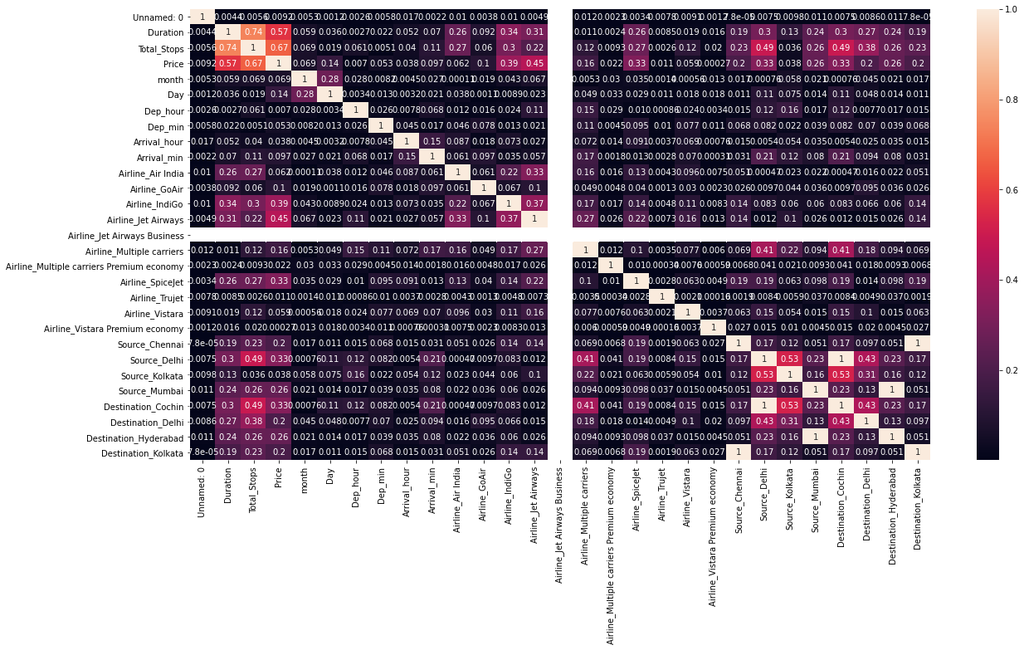

```python
# full correlation table
plt.figure(figsize=(20,10))
sns.heatmap(data_train.corr().abs(),annot=True)
```

- Total Stops and Duration are the coulmns which are mainly increasing the price or decreasing it .

```python
def test_set_preprocessing(test_set):
## Changing Date of Journey column Datatype
    test_set['Date_of_Journey']=pd.to_datetime(test_set['Date_of_Journey'])
    ## only taking arrival time ie hr:min some of values are '12:56 10 Mar'
    pattern='\d{2}:\d{2}'
    test_set['Arrival_Time']=test_set['Arrival_Time'].apply(lambda x:re.findall(pattern,x)[0])
    ## In Duration Column Adding 00m Where only Hr is given
    ## After that we Calualate total duration in minutes
    pattern='\d{1,2}\w\s\d{2}\w'
    Time=[]
    for time in test_set['Duration']:
        if re.findall(pattern,time):
            Time.append(time)
        else:
            time=time+' '+'00m'
            Time.append(time)
    test_set['Duration']=Time
    hour=test_set['Duration'].apply(lambda x:x.split(' ')[0][:-1]).astype('int')
    minute=test_set['Duration'].apply(lambda x:x.split(' ')[1][:-1]).astype('int')
    test_set['Duration']=hour*60+minute
    ## extracting Day and month
    test_set['month']=test_set['Date_of_Journey'].dt.month
    test_set['Day']=test_set['Date_of_Journey'].dt.day
    test_set.drop('Date_of_Journey',axis=1,inplace=True)
    ## creating new col from dep_time .
    test_set['Dep_hour']=(test_set['Dep_Time'].apply(lambda x:x.split(':')[0])).astype('int')
    test_set['Dep_min']=(test_set['Dep_Time'].apply(lambda x:x.split(':')[1])).astype('int')
    ## creating new col from arrival_time
    test_set['Arrival_hour']=(test_set['Arrival_Time'].apply(lambda x:x.split(':')[0])).astype('int')
    test_set['Arrival_min']=(test_set['Arrival_Time'].apply(lambda x:x.split(':')[1])).astype('int')
    test_set.drop(['Arrival_Time','Dep_Time'],1,inplace=True)
    # As this is case of Ordinal Categorical type we perform LabelEncoder
    # Here Values are assigned with corresponding keys
    test_set['Total_Stops']=test_set['Total_Stops'].replace({"1 stop":1,'non-stop':0,'2 stops':2,'3 stops':3,'4 stops':3})
    # Additional_Info contains almost 80% no_info
    test_set.drop(['Additional_Info'],1,inplace=True)
    ## dropping the Route col from dataset
    test_set.drop(['Route'],1,inplace=True)
    ## # As Source is Nominal Categorical data we will perform OneHotEncoding
    source=pd.get_dummies(test_set[['Source']],drop_first=True)
    # As Destination is Nominal Categorical data we will perform OneHotEncoding
    destination=pd.get_dummies(test_set[['Destination']],drop_first=True)
    # As Airline is Nominal Categorical data we will perform OneHotEncoding
    airline=pd.get_dummies(test_set[['Airline']],drop_first=True)
    # Concatenate dataframe --> train_data + Airline + Source + Destination
    test_set = pd.concat([test_set, airline, source, destination], axis = 1)
    ##remove the Original columns
    test_set.drop(["Airline", "Source", "Destination"], axis = 1, inplace = True)
    return test_set
```

```python
data_train.drop('Airline_Trujet',1,inplace=True)
```

```python
data_train.info()
```

```
<class 'pandas.core.frame.DataFrame'>
Int64Index: 10588 entries, 0 to 10682
Data columns (total 28 columns):
 #   Column                                     Non-Null Count  Dtype
---  ------                                     --------------  -----
 0   Unnamed: 0                                 10588 non-null  int64
 1   Duration                                   10588 non-null  int32
 2   Total_Stops                                10588 non-null  int64
 3   Price                                      10588 non-null  int64
 4   month                                      10588 non-null  int64
 5   Day                                        10588 non-null  int64
 6   Dep_hour                                   10588 non-null  int32
 7   Dep_min                                    10588 non-null  int32
 8   Arrival_hour                               10588 non-null  int32
 9   Arrival_min                                10588 non-null  int32
```

[output cut: 20 more lines]

```python
## Taking out the numerical columns
normalization=['Duration','Total_Stops','month','Day','Dep_hour','Dep_min','Arrival_hour','Arrival_min']
```

```python
data_train[normalization].head()
```

|  | Duration | Total_Stops | month | Day | Dep_hour | Dep_min | Arrival_hour | Arrival_min |
| --- | --- | --- | --- | --- | --- | --- | --- | --- |
| 0 | 170 | 0 | 3 | 24 | 22 | 20 | 1 | 10 |
| 1 | 445 | 2 | 1 | 5 | 5 | 50 | 13 | 15 |
| 2 | 1140 | 2 | 9 | 6 | 9 | 25 | 4 | 25 |
| 3 | 325 | 1 | 12 | 5 | 18 | 5 | 23 | 30 |
| 4 | 285 | 1 | 1 | 3 | 16 | 50 | 21 | 35 |

```python
data_train
```

|  | Unnamed: 0 | Duration | Total_Stops | Price | month | Day | Dep_hour | Dep_min | Arrival_hour | Arrival_min | ... | Airline_Vistara | Airline_Vistara Premium economy | Source_Chennai | Source_Delhi | Source_Kolkata | Source_Mumbai | Destination_Cochin | Destination_Delhi | Destination_Hyderabad | Destination_Kolkata |
| --- | --- | --- | --- | --- | --- | --- | --- | --- | --- | --- | --- | --- | --- | --- | --- | --- | --- | --- | --- | --- | --- |
| 0 | 0 | 170 | 0 | 3897 | 3 | 24 | 22 | 20 | 1 | 10 | ... | 0 | 0 | 0 | 0 | 0 | 0 | 0 | 1 | 0 | 0 |
| 1 | 1 | 445 | 2 | 7662 | 1 | 5 | 5 | 50 | 13 | 15 | ... | 0 | 0 | 0 | 0 | 1 | 0 | 0 | 0 | 0 | 0 |
| 2 | 2 | 1140 | 2 | 13882 | 9 | 6 | 9 | 25 | 4 | 25 | ... | 0 | 0 | 0 | 1 | 0 | 0 | 1 | 0 | 0 | 0 |
| 3 | 3 | 325 | 1 | 6218 | 12 | 5 | 18 | 5 | 23 | 30 | ... | 0 | 0 | 0 | 0 | 1 | 0 | 0 | 0 | 0 | 0 |
| 4 | 4 | 285 | 1 | 13302 | 1 | 3 | 16 | 50 | 21 | 35 | ... | 0 | 0 | 0 | 0 | 0 | 0 | 0 | 1 | 0 | 0 |
| ... | ... | ... | ... | ... | ... | ... | ... | ... | ... | ... | ... | ... | ... | ... | ... | ... | ... | ... | ... | ... | ... |
| 10678 | 10678 | 150 | 0 | 4107 | 9 | 4 | 19 | 55 | 22 | 25 | ... | 0 | 0 | 0 | 0 | 1 | 0 | 0 | 0 | 0 | 0 |
| 10679 | 10679 | 155 | 0 | 4145 | 4 | 27 | 20 | 45 | 23 | 20 | ... | 0 | 0 | 0 | 0 | 1 | 0 | 0 | 0 | 0 | 0 |
| 10680 | 10680 | 180 | 0 | 7229 | 4 | 27 | 8 | 20 | 11 | 20 | ... | 0 | 0 | 0 | 0 | 0 | 0 | 0 | 1 | 0 | 0 |
| 10681 | 10681 | 160 | 0 | 12648 | 1 | 3 | 11 | 30 | 14 | 10 | ... | 1 | 0 | 0 | 0 | 0 | 0 | 0 | 1 | 0 | 0 |
| 10682 | 10682 | 500 | 2 | 11753 | 9 | 5 | 10 | 55 | 19 | 15 | ... | 0 | 0 | 0 | 1 | 0 | 0 | 1 | 0 | 0 | 0 |

10588 rows × 28 columns

## Train Test Split

```python
## create x and y
y=data_train.pop('Price')
X=data_train
```

```python
## Train Test split
X_train,X_test,y_train,y_test=train_test_split(X,y,train_size=.70,random_state=2)
```

```python
X_train
```

|  | Unnamed: 0 | Duration | Total_Stops | month | Day | Dep_hour | Dep_min | Arrival_hour | Arrival_min | Airline_Air India | ... | Airline_Vistara | Airline_Vistara Premium economy | Source_Chennai | Source_Delhi | Source_Kolkata | Source_Mumbai | Destination_Cochin | Destination_Delhi | Destination_Hyderabad | Destination_Kolkata |
| --- | --- | --- | --- | --- | --- | --- | --- | --- | --- | --- | --- | --- | --- | --- | --- | --- | --- | --- | --- | --- | --- |
| 5086 | 5086 | 80 | 0 | 3 | 15 | 5 | 45 | 7 | 5 | 0 | ... | 0 | 0 | 0 | 0 | 0 | 1 | 0 | 0 | 1 | 0 |
| 4182 | 4182 | 90 | 0 | 3 | 15 | 10 | 20 | 11 | 50 | 0 | ... | 0 | 0 | 0 | 0 | 0 | 1 | 0 | 0 | 1 | 0 |
| 833 | 833 | 660 | 1 | 9 | 4 | 8 | 0 | 19 | 0 | 0 | ... | 0 | 0 | 0 | 1 | 0 | 0 | 1 | 0 | 0 | 0 |
| 7953 | 7953 | 1100 | 1 | 6 | 24 | 18 | 15 | 12 | 35 | 0 | ... | 0 | 0 | 0 | 1 | 0 | 0 | 1 | 0 | 0 | 0 |
| 8771 | 8771 | 150 | 0 | 6 | 15 | 17 | 10 | 19 | 40 | 0 | ... | 0 | 0 | 0 | 0 | 1 | 0 | 0 | 0 | 0 | 0 |
| ... | ... | ... | ... | ... | ... | ... | ... | ... | ... | ... | ... | ... | ... | ... | ... | ... | ... | ... | ... | ... | ... |
| 1112 | 1112 | 90 | 0 | 6 | 21 | 21 | 20 | 22 | 50 | 0 | ... | 0 | 0 | 0 | 0 | 0 | 1 | 0 | 0 | 1 | 0 |
| 2541 | 2541 | 90 | 0 | 1 | 6 | 10 | 20 | 11 | 50 | 0 | ... | 0 | 0 | 0 | 0 | 0 | 1 | 0 | 0 | 1 | 0 |
| 6695 | 6695 | 145 | 0 | 4 | 21 | 9 | 0 | 11 | 25 | 0 | ... | 0 | 0 | 0 | 0 | 1 | 0 | 0 | 0 | 0 | 0 |
| 2603 | 2603 | 165 | 0 | 1 | 4 | 6 | 5 | 8 | 50 | 0 | ... | 0 | 0 | 0 | 0 | 0 | 0 | 0 | 1 | 0 | 0 |
| 7398 | 7398 | 290 | 1 | 3 | 6 | 15 | 10 | 20 | 0 | 0 | ... | 0 | 0 | 0 | 1 | 0 | 0 | 1 | 0 | 0 | 0 |

7411 rows × 27 columns

```python
## creating the object of the standard scaler
scaler=StandardScaler()
X_train[normalization]=scaler.fit_transform(X_train[normalization])
## For test set
X_test[normalization]=scaler.transform(X_test[normalization])
```

```python
X_train
```

|  | Unnamed: 0 | Duration | Total_Stops | month | Day | Dep_hour | Dep_min | Arrival_hour | Arrival_min | Airline_Air India | ... | Airline_Vistara | Airline_Vistara Premium economy | Source_Chennai | Source_Delhi | Source_Kolkata | Source_Mumbai | Destination_Cochin | Destination_Delhi | Destination_Hyderabad | Destination_Kolkata |
| --- | --- | --- | --- | --- | --- | --- | --- | --- | --- | --- | --- | --- | --- | --- | --- | --- | --- | --- | --- | --- | --- |
| 5086 | 5086 | -1.104934 | -1.212337 | -0.873326 | 0.259486 | -1.301938 | 1.098428 | -0.920931 | -1.196828 | 0 | ... | 0 | 0 | 0 | 0 | 0 | 1 | 0 | 0 | 1 | 0 |
| 4182 | 4182 | -1.085168 | -1.212337 | -0.873326 | 0.259486 | -0.433550 | -0.236072 | -0.338666 | 1.541765 | 0 | ... | 0 | 0 | 0 | 0 | 0 | 1 | 0 | 0 | 1 | 0 |
| 833 | 833 | 0.041545 | 0.261519 | 1.141164 | -0.991388 | -0.780905 | -1.303671 | 0.825865 | -1.501117 | 0 | ... | 0 | 0 | 0 | 1 | 0 | 0 | 1 | 0 | 0 | 0 |
| 7953 | 7953 | 0.911288 | 0.261519 | 0.133919 | 1.282928 | 0.955872 | -0.502972 | -0.193100 | 0.628900 | 0 | ... | 0 | 0 | 0 | 1 | 0 | 0 | 1 | 0 | 0 | 0 |
| 8771 | 8771 | -0.966566 | -1.212337 | 0.133919 | 0.259486 | 0.782194 | -0.769872 | 0.825865 | 0.933189 | 0 | ... | 0 | 0 | 0 | 0 | 1 | 0 | 0 | 0 | 0 | 0 |
| ... | ... | ... | ... | ... | ... | ... | ... | ... | ... | ... | ... | ... | ... | ... | ... | ... | ... | ... | ... | ... | ... |
| 1112 | 1112 | -1.085168 | -1.212337 | 0.133919 | 0.941781 | 1.476905 | -0.236072 | 1.262563 | 1.541765 | 0 | ... | 0 | 0 | 0 | 0 | 0 | 1 | 0 | 0 | 1 | 0 |
| 2541 | 2541 | -1.085168 | -1.212337 | -1.544823 | -0.763957 | -0.433550 | -0.236072 | -0.338666 | 1.541765 | 0 | ... | 0 | 0 | 0 | 0 | 0 | 1 | 0 | 0 | 1 | 0 |
| 6695 | 6695 | -0.976450 | -1.212337 | -0.537578 | 0.941781 | -0.607228 | -1.303671 | -0.338666 | 0.020324 | 0 | ... | 0 | 0 | 0 | 0 | 1 | 0 | 0 | 0 | 0 | 0 |
| 2603 | 2603 | -0.936916 | -1.212337 | -1.544823 | -0.991388 | -1.128261 | -1.036772 | -0.775365 | 1.541765 | 0 | ... | 0 | 0 | 0 | 0 | 0 | 0 | 0 | 1 | 0 | 0 |
| 7398 | 7398 | -0.689830 | 0.261519 | -0.873326 | -0.763957 | 0.434839 | -0.769872 | 0.971431 | -1.501117 | 0 | ... | 0 | 0 | 0 | 1 | 0 | 0 | 1 | 0 | 0 | 0 |

7411 rows × 27 columns

```python
## creating to store model Predictioon
d={'Model_Name':[],'r2_score_on_trainSet':[],'r2_score_on_testSet':[],'mean_square_trainSet':[],'mean_square_testSet':[]}
```

## Model Building

```python
def Model(model):
    model1=model[0]
    model1.fit(X_train,y_train)
    y_train_pred=model1.predict(X_train)
    y_test_pred=model1.predict(X_test)
    d['Model_Name'].append(model[1])
    d['r2_score_on_trainSet'].append(r2_score(y_train,y_train_pred))
    d['r2_score_on_testSet'].append(r2_score(y_test,y_test_pred))
    d['mean_square_trainSet'].append((mean_squared_error(y_train,y_train_pred)).round(2))
    d['mean_square_testSet'].append((mean_squared_error(y_test,y_test_pred)).round(2))
    return d
```

```python
## Taking all the model
models=[(LinearRegression(),'Linear Regression'),(RandomForestRegressor(),'RandomForest'),(DecisionTreeRegressor(),'descisionTree'),(KNeighborsRegressor(),'KNN'),(AdaBoostRegressor(),'AdaBoost'),(GradientBoostingRegressor(),'GBR'),(XGBRegressor(),'XGB')]
for model in models:
    k=Model(model)
df=pd.DataFrame(k)
df
```

|  | Model_Name | r2_score_on_trainSet | r2_score_on_testSet | mean_square_trainSet | mean_square_testSet |
| --- | --- | --- | --- | --- | --- |
| 0 | Linear Regression | 0.626922 | 0.628836 | 6242220.27 | 5982929.89 |
| 1 | RandomForest | 0.976553 | 0.844564 | 392305.44 | 2505528.03 |
| 2 | descisionTree | 1.000000 | 0.722398 | 0.00 | 4474773.31 |
| 3 | KNN | 0.297780 | -0.084544 | 11749306.11 | 17482161.86 |
| 4 | AdaBoost | 0.570061 | 0.537554 | 7193591.93 | 7454327.45 |
| 5 | GBR | 0.791543 | 0.782325 | 3487830.22 | 3508784.23 |
| 6 | XGB | 0.941920 | 0.839834 | 971773.56 | 2581773.11 |

```python
## GradientBoostingRegressor

GBR=GradientBoostingRegressor(max_depth=4, max_features=20, min_samples_leaf=3,
                          min_samples_split=10, n_estimators=750,
                          random_state=10, subsample=0.8)
GBR.fit(X_train,y_train)
```

```
GradientBoostingRegressor(max_depth=4, max_features=20, min_samples_leaf=3,
                          min_samples_split=10, n_estimators=750,
                          random_state=10, subsample=0.8)
```

```python
print('Test Set r2 Ssore',r2_score(y_test,GBR.predict(X_test)))
print('Train set r2 Score',r2_score(y_train,GBR.predict(X_train)))
```

```
Test Set r2 Ssore 0.8390224248757969
Train set r2 Score 0.9237157200769573
```

```python
### RandomForestRegressor
rfc=RandomForestRegressor(max_depth=25, max_features=20, min_samples_leaf=2,min_samples_split=10, n_estimators=100,n_jobs=-1)
```

```python
rfc.fit(X_train,y_train)
```

```
RandomForestRegressor(max_depth=25, max_features=20, min_samples_leaf=2,
                      min_samples_split=10, n_jobs=-1)
```

```python
print('Test Set r2 Ssore',r2_score(y_test,rfc.predict(X_test)))
print('Train set r2 Score',r2_score(y_train,rfc.predict(X_train)))
```

```
Test Set r2 Ssore 0.8436586253021243
Train set r2 Score 0.9238921765581735
```

```python
xgb=XGBRegressor(n_estimators=1500,min_child_weight=2,max_depth=5,learning_rate=0.05, booster='gbtree',base_score=1)
xgb.fit(X_train,y_train)
```

```
XGBRegressor(base_score=1, booster='gbtree', colsample_bylevel=1,
             colsample_bynode=1, colsample_bytree=1, enable_categorical=False,
             gamma=0, gpu_id=-1, importance_type=None,
             interaction_constraints='', learning_rate=0.05, max_delta_step=0,
             max_depth=5, min_child_weight=2, missing=nan,
             monotone_constraints='()', n_estimators=1500, n_jobs=16,
             num_parallel_tree=1, predictor='auto', random_state=0, reg_alpha=0,
             reg_lambda=1, scale_pos_weight=1, subsample=1, tree_method='exact',
             validate_parameters=1, verbosity=None)
```

```python
for model in[(GBR,'GBR+Hyperparameter'),(xgb,'XGB+Hyperparamter'),(rfc,'RFC+Hyperparameter')]:
    s=Model(model)
    y=pd.DataFrame(s)
```

```python
y.style.background_gradient(cmap='viridis')
```

|  | Model_Name | r2_score_on_trainSet | r2_score_on_testSet | mean_square_trainSet | mean_square_testSet |
| --- | --- | --- | --- | --- | --- |
| 0 | Linear Regression | 0.626922 | 0.628836 | 6242220.270000 | 5982929.890000 |
| 1 | RandomForest | 0.976553 | 0.844564 | 392305.440000 | 2505528.030000 |
| 2 | descisionTree | 1.000000 | 0.722398 | 0.000000 | 4474773.310000 |
| 3 | KNN | 0.297780 | -0.084544 | 11749306.110000 | 17482161.860000 |
| 4 | AdaBoost | 0.570061 | 0.537554 | 7193591.930000 | 7454327.450000 |
| 5 | GBR | 0.791543 | 0.782325 | 3487830.220000 | 3508784.230000 |
| 6 | XGB | 0.941920 | 0.839834 | 971773.560000 | 2581773.110000 |
| 7 | GBR+Hyperparameter | 0.923716 | 0.839022 | 1276362.310000 | 2594855.380000 |
| 8 | XGB+Hyperparamter | 0.953833 | 0.844145 | 772452.290000 | 2512275.240000 |
| 9 | RFC+Hyperparameter | 0.925158 | 0.846924 | 1252223.910000 | 2467490.580000 |

```python
fig=px.bar(data_frame=y,x='Model_Name',y='r2_score_on_testSet',title='Models')
fig.show()
```

[interactive chart not shown]

```python
feature_importance=pd.DataFrame({'Column_Name':X_train.columns,'Feature_Importance':GBR.feature_importances_})
feature_importance
```

|  | Column_Name | Feature_Importance |
| --- | --- | --- |
| 0 | Unnamed: 0 | 0.038588 |
| 1 | Duration | 0.496154 |
| 2 | Total_Stops | 0.095923 |
| 3 | month | 0.036298 |
| 4 | Day | 0.100792 |
| 5 | Dep_hour | 0.018460 |
| 6 | Dep_min | 0.018856 |
| 7 | Arrival_hour | 0.025225 |
| 8 | Arrival_min | 0.016540 |
| 9 | Airline_Air India | 0.004636 |
| 10 | Airline_GoAir | 0.003268 |
| 11 | Airline_IndiGo | 0.028699 |
| 12 | Airline_Jet Airways | 0.069703 |
| 13 | Airline_Jet Airways Business | 0.000000 |
| 14 | Airline_Multiple carriers | 0.017038 |
| 15 | Airline_Multiple carriers Premium economy | 0.000797 |
| 16 | Airline_SpiceJet | 0.003538 |
| 17 | Airline_Vistara | 0.005023 |
| 18 | Airline_Vistara Premium economy | 0.000000 |
| 19 | Source_Chennai | 0.000141 |
| 20 | Source_Delhi | 0.002913 |
| 21 | Source_Kolkata | 0.008223 |
| 22 | Source_Mumbai | 0.001427 |
| 23 | Destination_Cochin | 0.001827 |
| 24 | Destination_Delhi | 0.003903 |
| 25 | Destination_Hyderabad | 0.001570 |
| 26 | Destination_Kolkata | 0.000456 |

```python
fig=px.bar(data_frame=feature_importance,x='Column_Name',y='Feature_Importance',title='Top Feature')
fig.show()
```

[interactive chart not shown]

```python
def test_set_preprocessing(test_set):
## Changing Date of Journey column Datatype
    test_set['Date_of_Journey']=pd.to_datetime(test_set['Date_of_Journey'])
    ## only taking arrival time ie hr:min some of values are '12:56 10 Mar'
    pattern='\d{2}:\d{2}'
    test_set['Arrival_Time']=test_set['Arrival_Time'].apply(lambda x:re.findall(pattern,x)[0])
    ## In Duration Column Adding 00m Where only Hr is given
    ## After that we Calualate total duration in minutes
    pattern='\d{1,2}\w\s\d{2}\w'
    Time=[]
    for time in test_set['Duration']:
        if re.findall(pattern,time):
            Time.append(time)
        else:
            time=time+' '+'00m'
            Time.append(time)
    test_set['Duration']=Time
    hour=test_set['Duration'].apply(lambda x:x.split(' ')[0][:-1]).astype('int')
    minute=test_set['Duration'].apply(lambda x:x.split(' ')[1][:-1]).astype('int')
    test_set['Duration']=hour*60+minute
    ## extracting Day and month
    test_set['month']=test_set['Date_of_Journey'].dt.month
    test_set['Day']=test_set['Date_of_Journey'].dt.day
    test_set.drop('Date_of_Journey',axis=1,inplace=True)
    ## creating new col from dep_time .
    test_set['Dep_hour']=(test_set['Dep_Time'].apply(lambda x:x.split(':')[0])).astype('int')
    test_set['Dep_min']=(test_set['Dep_Time'].apply(lambda x:x.split(':')[1])).astype('int')
    ## creating new col from arrival_time
    test_set['Arrival_hour']=(test_set['Arrival_Time'].apply(lambda x:x.split(':')[0])).astype('int')
    test_set['Arrival_min']=(test_set['Arrival_Time'].apply(lambda x:x.split(':')[1])).astype('int')
    test_set.drop(['Arrival_Time','Dep_Time'],1,inplace=True)
    # As this is case of Ordinal Categorical type we perform LabelEncoder
    # Here Values are assigned with corresponding keys
    test_set['Total_Stops']=test_set['Total_Stops'].replace({"1 stop":1,'non_stop':0,'2 stops':2,'3 stops':3,'4 stops':3})
    # Additional_Info contains almost 80% no_info
    test_set.drop(['Additional_Info'],1,inplace=True)
    ## dropping the Route col from dataset
    test_set.drop(['Route'],1,inplace=True)
    ## # As Source is Nominal Categorical data we will perform OneHotEncoding
    source=pd.get_dummies(test_set[['Source']],drop_first=True)
    # As Destination is Nominal Categorical data we will perform OneHotEncoding
    destination=pd.get_dummies(test_set[['Destination']],drop_first=True)
    # As Airline is Nominal Categorical data we will perform OneHotEncoding
    airline=pd.get_dummies(test_set[['Airline']],drop_first=True)
    # Concatenate dataframe --> train_data + Airline + Source + Destination
    test_set = pd.concat([test_set, airline, source, destination], axis = 1)
    ##remove the Original columns
    test_set.drop(["Airline", "Source", "Destination"], axis = 1, inplace = True)
    ## Taking out the numerical columns
#     normalization=['Duration','Total_Stops','month','Day','Dep_hour','Dep_min','Arrival_hour','Arrival_min']
#     test_set[normalization]=scaler.transform(test_set[normalization])
    return test_set
```

```python
import pickle
```

```python
GBR
```

```
GradientBoostingRegressor(max_depth=4, max_features=20, min_samples_leaf=3,
                          min_samples_split=10, n_estimators=750,
                          random_state=10, subsample=0.8)
```

```python
data = {"model": rfc,  "Noramlization": scaler}
```

```python
filename = 'finalized.pkl'
pickle.dump(data, open(filename, 'wb'))
```

```python
loaded_model = pickle.load(open('finalized_model.pkl', 'rb'))
```

```python
model=loaded_model['model']
```

```python
s=model.predict(X_train[:1])
s
```

```
array([2398.72473253])
```